# Quality control and filtering: New Multiome cases Barcelona

Ramon Massoni-Badosa

2023-04-17

# 1 Objective

The objective of this notebook is to create a Seurat object, assess the quality of the data and filter out the low-quality cells. We followed the procedure described by a specific Signac’s vignette entitled [“Joint RNA and ATAC analysis: 10x multiomic”](https://satijalab.org/signac/articles/pbmc_multiomic.html).

# 2 Pre-processing

## 2.1 Load packages

```r
library(Signac)
library(Seurat)
library(scDblFinder)
library(ggplot2)
library(ggpubr)
library(tidyverse)
library(plyr)
library(reshape2)
library(data.table)
library(GenomicRanges)
library(ensembldb)
library(EnsDb.Hsapiens.v86)
library(hdf5r)
library(stringr)
library(here)
library(glue)
library(future)
set.seed(173)
```

## 2.2 Parameters

```r
# Thresholds
TSS_enrichment <- 2
nucleosome_signal_atac <- 2
min_lib_size_atac<- 500

min_lib_size_rna <- 550
min_n_genes <- 250
max_pct_mt <- 20
min_cells <- 5
```

## 2.3 Functions

```r
plot_histogram_qc <- function(df, x, x_lab) {
  df %>%
    ggplot(aes_string(x)) +
    geom_histogram(bins = 100) +
    labs(x = x_lab, y = "Number of Cells") +
    theme_pubr()
}
```

## 2.4 Gene annotation

Extraction of gene annotations from EnsDb using hg38 as the reference assembly.

```r
annotation <- GetGRangesFromEnsDb(ensdb = EnsDb.Hsapiens.v86)
seqlevelsStyle(annotation) <- "UCSC"
genome(annotation) <- "hg38"
```

## 2.5 Load data

Signac uses information from three related input files (created using CellRanger ARC):

1. Count matrix in h5 format
2. ATAC Fragment file
3. ATAC Fragment file index

```r
path_to_experiment3 <- here("multiome/1-cellranger_mapping/projects/experiment_3/jobs")
gem_ids <- list.dirs(path_to_experiment3, full.names = FALSE, recursive = FALSE)
counts_l_l <- map(gem_ids, \(x) {
  path_to_file <- glue("{path_to_experiment3}/{x}/{x}/outs/filtered_feature_bc_matrix.h5")
  counts_l <- Read10X_h5(path_to_file)
  counts_l
})
names(counts_l_l) <- gem_ids
```

## 2.6 Create Seurat objects

```r
seurat_list <- map2(counts_l_l, gem_ids, \(l, x) {
  seurat_obj <- Seurat::CreateSeuratObject(
    counts = l$`Gene Expression`,
    assay = "RNA"
  )
  seurat_obj[["ATAC"]] <- Signac::CreateChromatinAssay(
    counts = l$Peaks,
    sep = c(":", "-"),
    genome = "hg38",
    fragments = glue("{path_to_experiment3}/{x}/{x}/outs/atac_fragments.tsv.gz"),
    annotation = annotation
  )
  seurat_obj$gem_id <- x
  seurat_obj <- RenameCells(seurat_obj, add.cell.id = x)
  seurat_obj
})
seurat_list
```

```
## $hagf3y16_sldip2ou
## An object of class Seurat
## 126524 features across 8662 samples within 2 assays
## Active assay: RNA (36601 features, 0 variable features)
##  1 other assay present: ATAC
##
## $k8s4gkxa_phcaecsq
## An object of class Seurat
## 127726 features across 9242 samples within 2 assays
## Active assay: RNA (36601 features, 0 variable features)
##  1 other assay present: ATAC
##
## $ng2o8d1y_g4kzaifb
## An object of class Seurat
## 102700 features across 8565 samples within 2 assays
## Active assay: RNA (36601 features, 0 variable features)
##  1 other assay present: ATAC
##
## $zoxefjul_5m23u91h
## An object of class Seurat
## 104135 features across 9215 samples within 2 assays
## Active assay: RNA (36601 features, 0 variable features)
##  1 other assay present: ATAC
```

# 3 Quality control

We can compute per-cell quality metrics taking in account three specifics from DNA accessibility such as TSS.enrichment, nucleosome signal and nCount_ATAC and nCount_RNA from gene expression data.

```r
plan("multicore", workers = 16)
plan()
```

```
## multicore:
## - args: function (..., workers = 16, envir = parent.frame())
## - tweaked: TRUE
## - call: plan("multicore", workers = 16)
```

```r
options(future.globals.maxSize = 64 * 1024 ^ 3)
quality_control <- function(seurat_obj) {
  DefaultAssay(seurat_obj) <- "ATAC"
  seurat_obj <- NucleosomeSignal(object = seurat_obj)
  seurat_obj <- TSSEnrichment(object = seurat_obj, fast = FALSE)
  seurat_obj$high.tss <- ifelse(seurat_obj$TSS.enrichment > 2, "High", "Low")

  DefaultAssay(seurat_obj) <- "RNA"
  seurat_obj[["pct_mt"]] <- PercentageFeatureSet(seurat_obj, pattern = "^MT-")
  seurat_obj[["pct_ribosomal"]] <- PercentageFeatureSet(seurat_obj, pattern = "^RPS")

  return(seurat_obj)
}
seurat_list <- map(seurat_list, quality_control)
metadata_QC <- map_df(seurat_list, \(x) x@meta.data)
head(metadata_QC)
```

```
##                                         orig.ident nCount_RNA nFeature_RNA nCount_ATAC nFeature_ATAC            gem_id nucleosome_signal nucleosome_percentile TSS.enrichment TSS.percentile high.tss     pct_mt pct_ribosomal
## hagf3y16_sldip2ou_AAACAGCCACAAAGAC-1 SeuratProject       2851         1418       13682          5474 hagf3y16_sldip2ou         0.8387097                  0.75       4.106737           0.13     High  4.2792003      6.418800
## hagf3y16_sldip2ou_AAACAGCCATAATCCG-1 SeuratProject       9220         3360       25866          9408 hagf3y16_sldip2ou         0.6341241                  0.23       4.725771           0.40     High  3.4924078      3.590022
## hagf3y16_sldip2ou_AAACAGCCATACCCGG-1 SeuratProject      19083         2341       10852          4475 hagf3y16_sldip2ou         0.6753247                  0.33       4.757561           0.42     High  0.8960855      1.121417
## hagf3y16_sldip2ou_AAACAGCCATGTTGGC-1 SeuratProject        237          145        3288          1506 hagf3y16_sldip2ou         0.5645695                  0.10       5.331177           0.72     High 16.8776371     14.345992
## hagf3y16_sldip2ou_AAACATGCAAGTCGCT-1 SeuratProject       1463          868        4757          2126 hagf3y16_sldip2ou         0.6616915                  0.29       6.902686           0.96     High  5.1264525      3.349282
## hagf3y16_sldip2ou_AAACATGCAATAATGG-1 SeuratProject       2870         1477        8197          3557 hagf3y16_sldip2ou         0.7351632                  0.48       5.270786           0.69     High  4.1114983      5.156794
```

## 3.1 scATAC parameters

### 3.1.1 Number of detected peaks

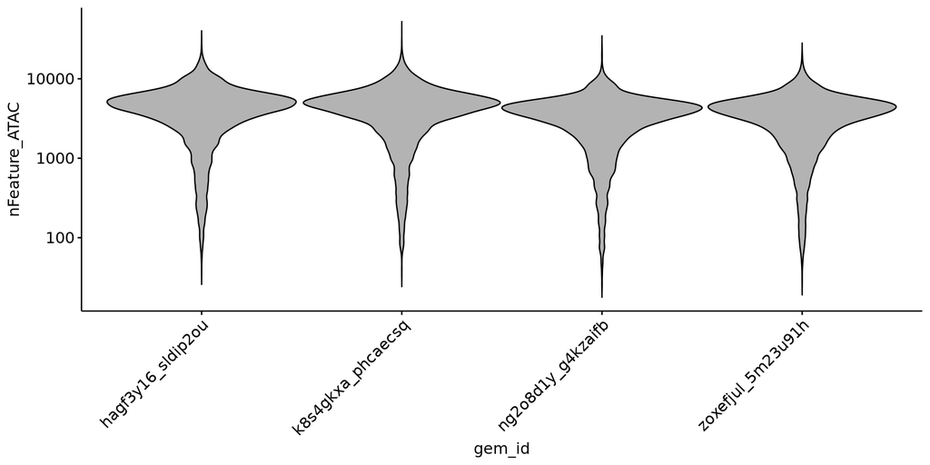

```r
np <- ggviolin(metadata_QC,
  x = "gem_id", fill = "gray70", x.text.angle = 45,
  y = "nFeature_ATAC") + scale_y_log10()
np
```

```r
print(paste("The median of total number of peaks is:", median(metadata_QC$nFeature_ATAC)))
```

```
## [1] "The median of total number of peaks is: 3845"
```

```r
print("The summary of total number of peaks per library")
```

```
## [1] "The summary of total number of peaks per library"
```

```r
aggregate(nFeature_ATAC ~ gem_id, data = metadata_QC, median)
```

```
##              gem_id nFeature_ATAC
## 1 hagf3y16_sldip2ou        4265.0
## 2 k8s4gkxa_phcaecsq        4286.5
## 3 ng2o8d1y_g4kzaifb        3444.0
## 4 zoxefjul_5m23u91h        3528.0
```

### 3.1.2 Nucleosome banding pattern

```r
nbp <- function(seurat_obj) {
  DefaultAssay(seurat_obj) <- "ATAC"
  f <- FragmentHistogram(object = seurat_obj)

  NFR <- length(which(f$data$length < 147)) / nrow(f$data) * 100
  MONO <- length(which(f$data$length > 147 & f$data$length < 294)) / nrow(f$data) * 100
  DI <- length(which(f$data$length > 294)) / nrow(f$data) * 100

  min.threshold <- 147
  max.threshold <- 294

  # options(repr.plot.width=7, repr.plot.height=2)
  options(repr.plot.width = 17, repr.plot.height = 8)
  p <- ggplot(f$data, aes(length)) + ggtitle(unique(seurat_obj$gem_id)) +
    geom_histogram(binwidth = 1, alpha = .5, fill = "blue") +
    geom_density(aes(y = ..count..), bw = 1, alpha = 0, col = "black", lwd = 1) +
    scale_x_continuous(limits = c(0, 500)) +
    geom_vline(xintercept = c(min.threshold, max.threshold)) +
    theme_minimal() +
    geom_vline(xintercept = 39, color = "red") +
    geom_text(x = 80, y = 20, label = round(NFR, 2), size = 8) +
    geom_text(x = 200, y = 20, label = round(MONO, 2), size = 8) +
    geom_text(x = 350, y = 20, label = round(DI, 2), size = 8)
  return(p)
}
```

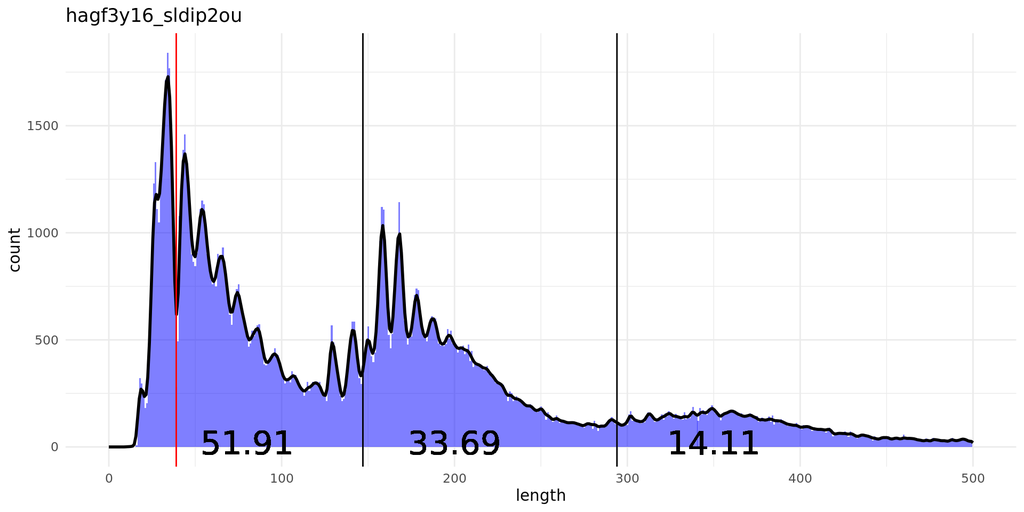

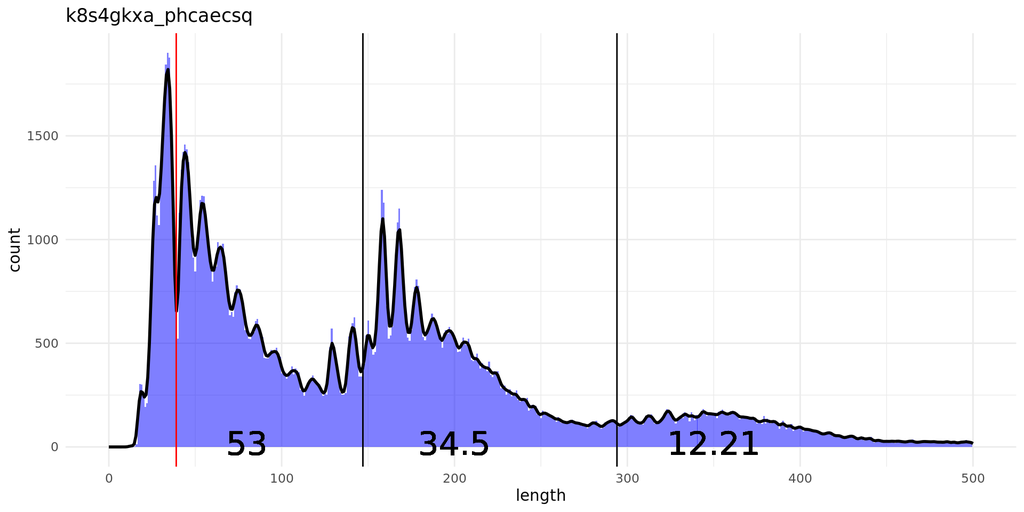

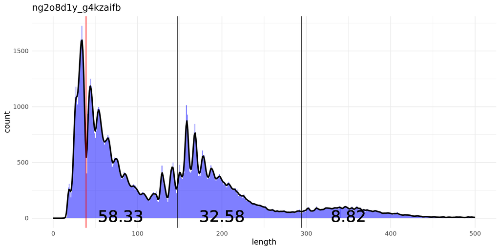

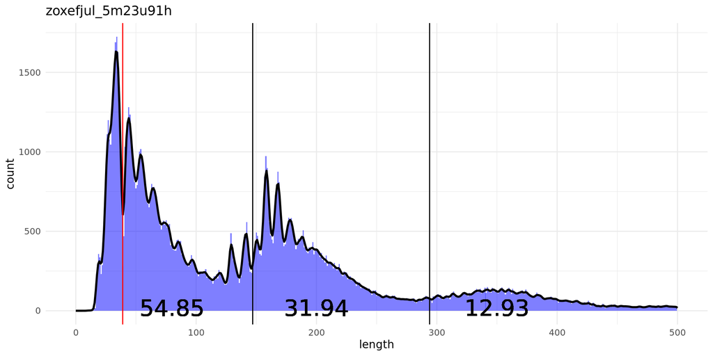

```r
plot_nbp <- map(seurat_list, nbp)
plot_nbp
```

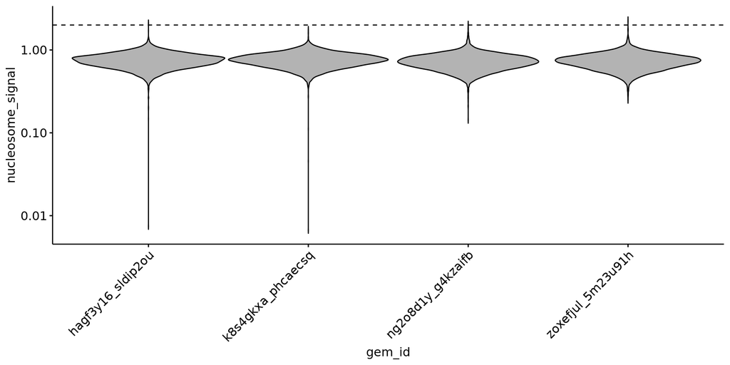

```r
ns <- ggviolin(metadata_QC,
  x = "gem_id", fill = "gray70", x.text.angle = 45,
  y = "nucleosome_signal") + scale_y_log10() + geom_hline(yintercept = nucleosome_signal_atac, linetype='dashed', col = 'black')
ns
```

### 3.1.3 Transcriptional start site (TSS) enrichment score

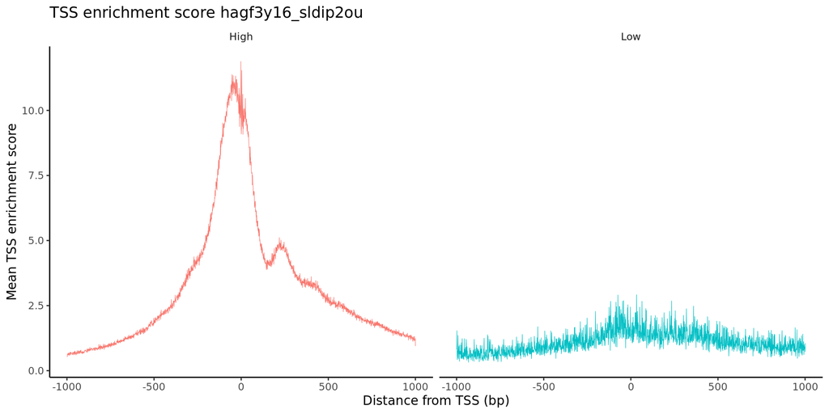

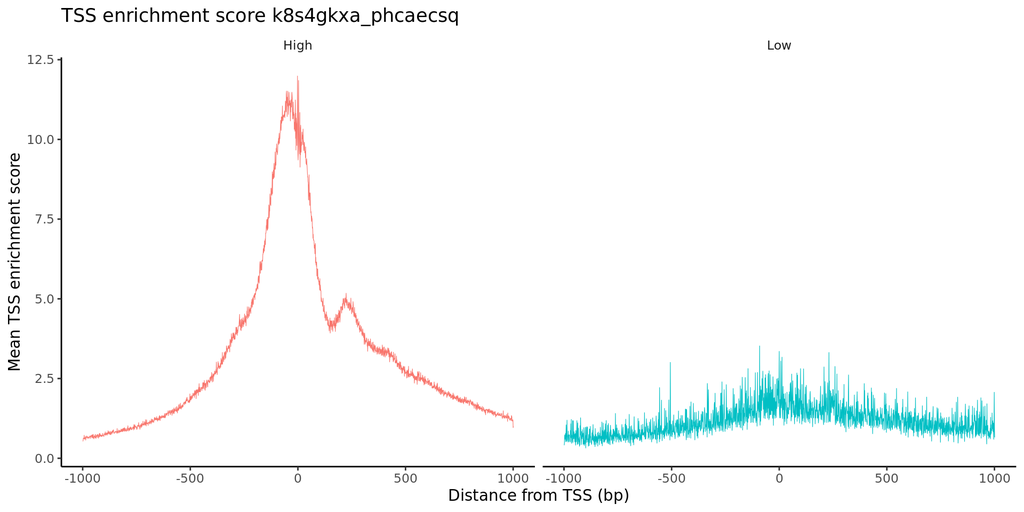

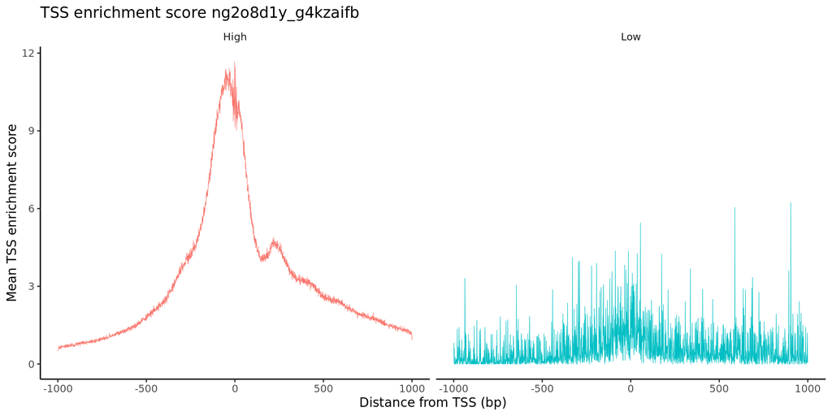

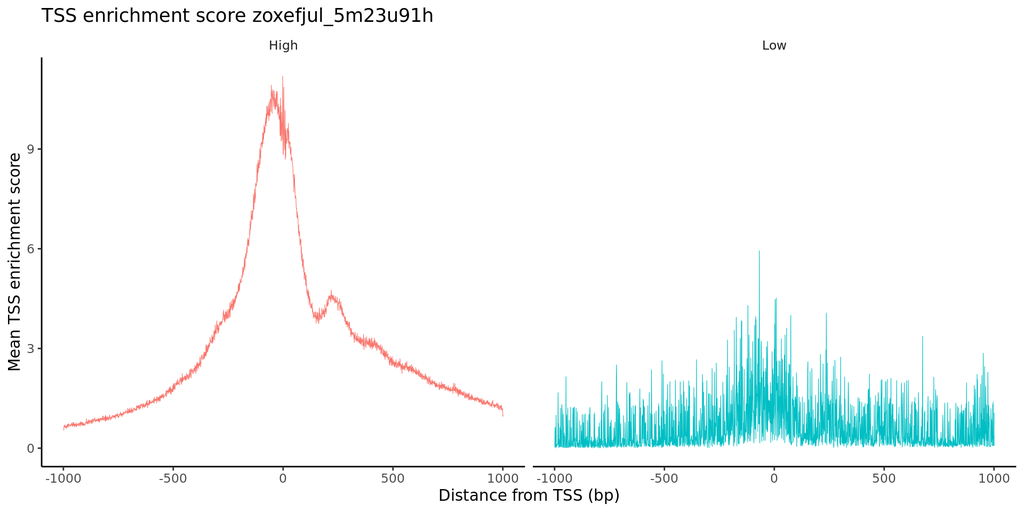

```r
plot_tss <- function(seurat_obj) {
 DefaultAssay(seurat_obj) <- "ATAC"
 p <- Signac::TSSPlot(seurat_obj, group.by = "high.tss") +
   ggtitle(paste("TSS enrichment score", unique(seurat_obj$gem_id)))
 p
}
plots_tss_tonsil <- map(seurat_list, plot_tss)
plots_tss_tonsil
```

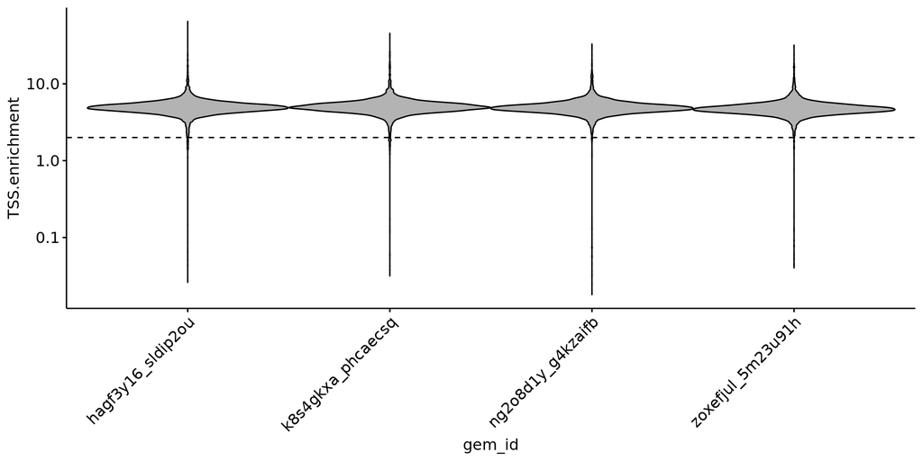

```r
tss <- ggviolin(metadata_QC,
  x = "gem_id", fill = "gray70", x.text.angle = 45,
  y = "TSS.enrichment") + geom_hline(yintercept = (2), linetype='dashed', col = 'black') + scale_y_log10()
tss
```

### 3.1.4 Library size

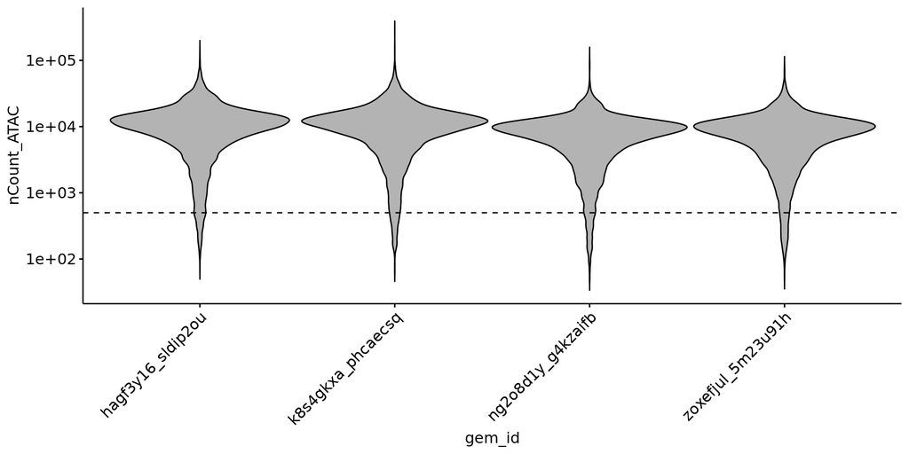

```r
ns <- ggviolin(metadata_QC,
  x = "gem_id", fill = "gray70", x.text.angle = 45,
  y = "nCount_ATAC") +  scale_y_log10() +
  geom_hline(yintercept = min_lib_size_atac, linetype='dashed', col = 'black')
ns
```

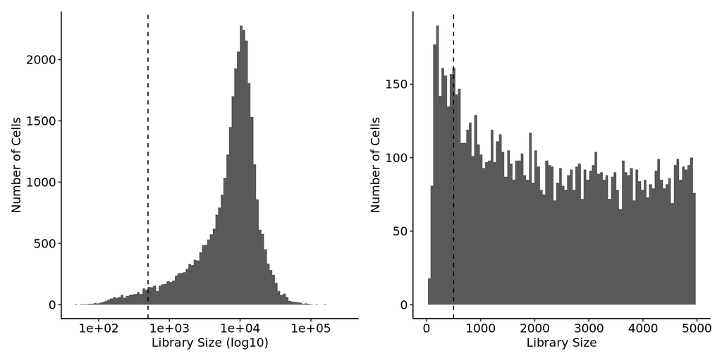

```r
lib_size_hist <- metadata_QC  %>%
  plot_histogram_qc(x = "nCount_ATAC", x_lab = "Library Size (log10)") +
  geom_vline(xintercept = min_lib_size_atac, linetype = "dashed", color = "black")
lib_size_hist1 <- lib_size_hist +
    scale_x_log10()
lib_size_hist2 <- lib_size_hist +
    scale_x_continuous(limits = c(0, 5000)) +
    xlab("Library Size") +
    theme_pubr()
lib_size_hist1 + lib_size_hist2
```

## 3.2 scRNA parameters

We aim to detect and exclude empty droplets or lysed cells. Lysed cells have 3 hallmarks: (1) low library size (total UMI), (2) low library complexity (number of detected genes) and (3) high fraction of mitochondrial expression (cytosolic mRNA leaks out of the cell). Let us start by visualizing their univariate distributions.

### 3.2.1 Library Size

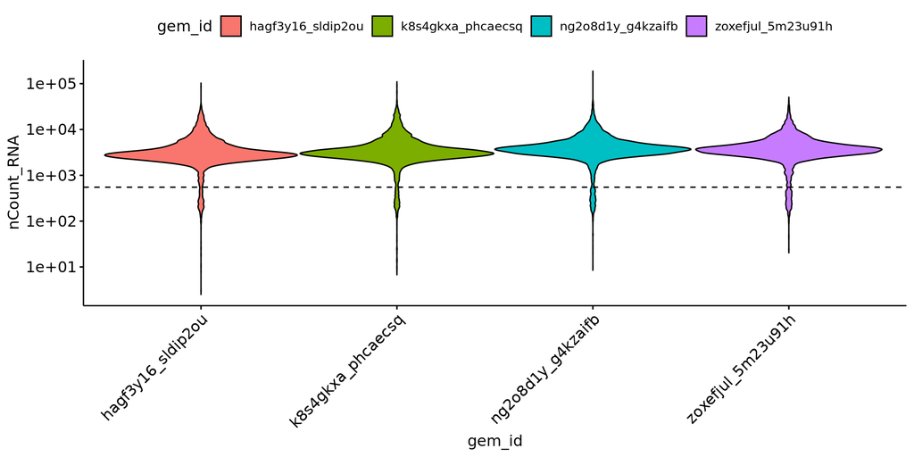

```r
nc <- ggviolin(metadata_QC,
  x = "gem_id", fill = "gem_id", x.text.angle = 45,
  y = "nCount_RNA") +  scale_y_log10() +
  geom_hline(yintercept = min_lib_size_rna, linetype='dashed', col = 'black')
nc
```

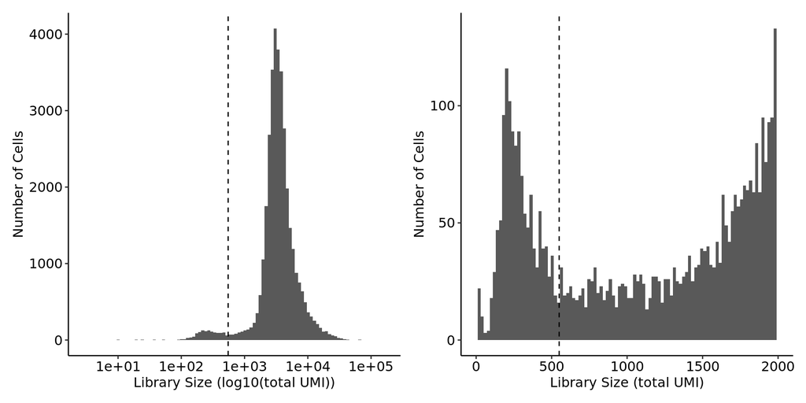

```r
lib_size_hist <- metadata_QC  %>%
  plot_histogram_qc(x = "nCount_RNA", x_lab = "Library Size (log10(total UMI))") +
  geom_vline(xintercept = min_lib_size_rna, linetype = "dashed", color = "black")
lib_size_hist1 <- lib_size_hist +
    scale_x_log10()
lib_size_hist2 <- lib_size_hist +
    scale_x_continuous(limits = c(0, 2000)) +
    xlab("Library Size (total UMI)") +
    theme_pubr()
lib_size_hist1 + lib_size_hist2
```

### 3.2.2 Number of detected genes

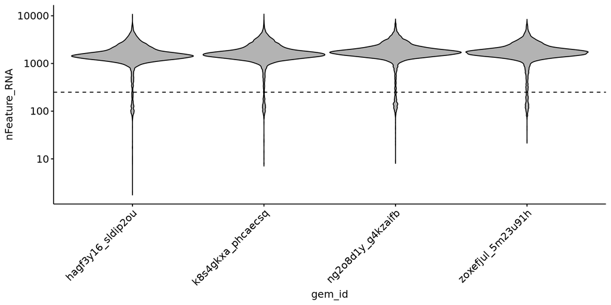

```r
ns <- ggviolin(metadata_QC,
  x = "gem_id", fill = "gray70", x.text.angle = 45,
  y = "nFeature_RNA") +  scale_y_log10() +
  geom_hline(yintercept = min_n_genes, linetype='dashed', col = 'black')
ns
```

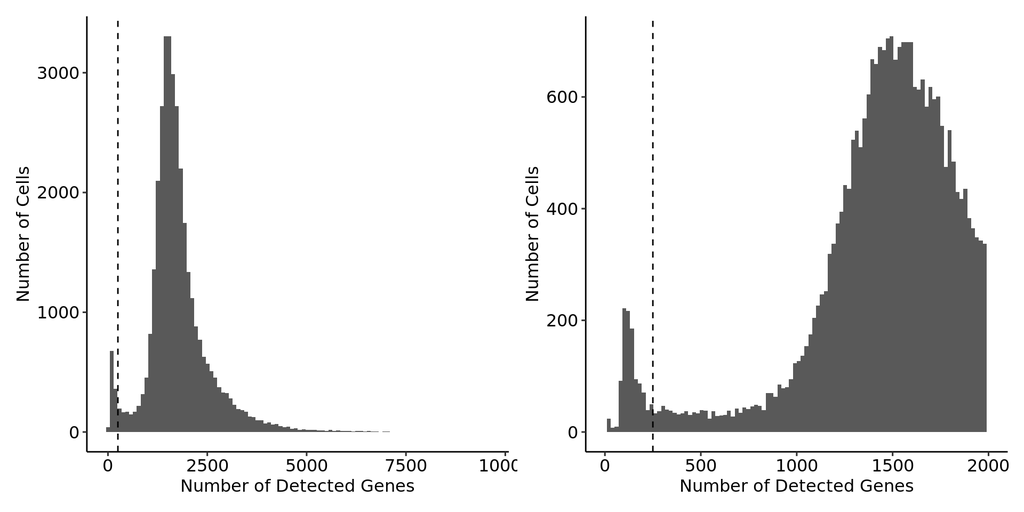

```r
n_genes_hist1 <- metadata_QC %>%
  plot_histogram_qc(x = "nFeature_RNA", x_lab = "Number of Detected Genes") +
  geom_vline(xintercept = min_n_genes, linetype = "dashed", color = "black")
n_genes_hist2 <- n_genes_hist1 +
  scale_x_continuous(limits = c(0, 2000))
n_genes_hist1 + n_genes_hist2
```

```r
print(paste("The median of total number of genes is:", median(metadata_QC$nFeature_RNA)))
```

```
## [1] "The median of total number of genes is: 1635"
```

```r
print("The summary of total number of genes per library")
```

```
## [1] "The summary of total number of genes per library"
```

```r
aggregate(nFeature_RNA ~ gem_id, data = metadata_QC, median)
```

```
##              gem_id nFeature_RNA
## 1 hagf3y16_sldip2ou       1492.5
## 2 k8s4gkxa_phcaecsq       1587.0
## 3 ng2o8d1y_g4kzaifb       1731.0
## 4 zoxefjul_5m23u91h       1716.0
```

### 3.2.3 Library Size vs library complexity

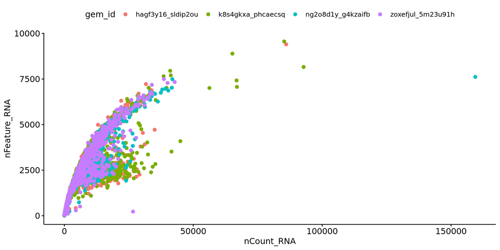

```r
ggscatter(metadata_QC, x = "nCount_RNA", y = "nFeature_RNA",
  color = "gem_id")
```

### 3.2.4 Fraction of mitochondrial expression

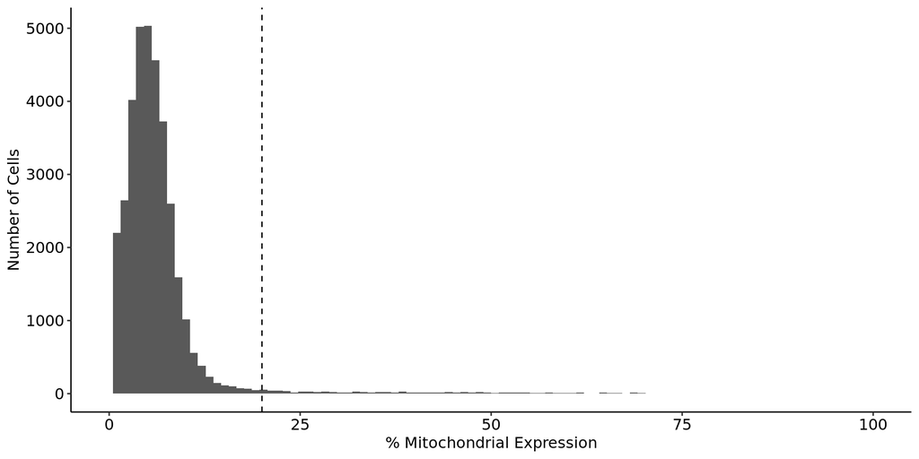

```r
pct_mt_hist <- metadata_QC %>%
  plot_histogram_qc(x = "pct_mt", x_lab = "% Mitochondrial Expression") +
  geom_vline(xintercept = max_pct_mt, linetype = "dashed", color = "black") +
  scale_x_continuous(limits = c(0, 100))

pct_mt_hist
```

### 3.2.5 Fraction of ribosomal expression

Let us also calculate and visualize the proportion of ribosomal expression:

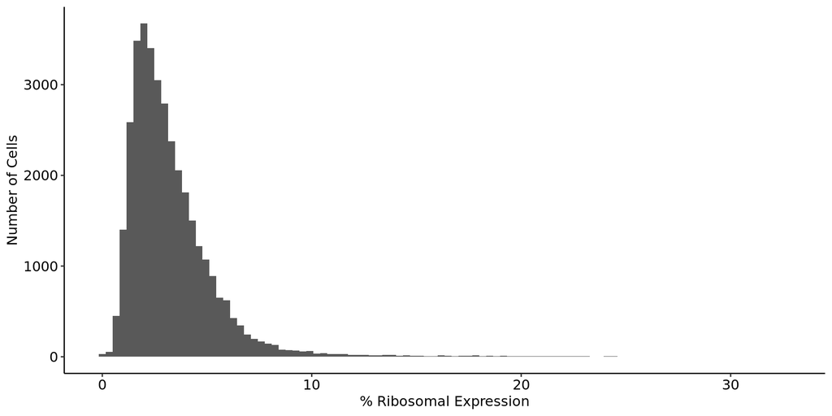

```r
metadata_QC %>%
  plot_histogram_qc(x = "pct_ribosomal", x_lab = "% Ribosomal Expression")
```

# 4 Filtering

Finally we remove cells that are outliers for these QC metrics.

```r
filtering_QC <- function(seurat_object) {
  seurat_object <- subset(
    x = seurat_object,
    pct_mt < max_pct_mt &
    nCount_ATAC > min_lib_size_atac &
    nCount_RNA > min_lib_size_rna &
    nFeature_RNA > min_n_genes &
    nucleosome_signal < nucleosome_signal_atac &
    TSS.enrichment > TSS_enrichment)
  return(seurat_object)
}
```

```r
seurat_list
```

```
## $hagf3y16_sldip2ou
## An object of class Seurat
## 126524 features across 8662 samples within 2 assays
## Active assay: RNA (36601 features, 0 variable features)
##  1 other assay present: ATAC
##
## $k8s4gkxa_phcaecsq
## An object of class Seurat
## 127726 features across 9242 samples within 2 assays
## Active assay: RNA (36601 features, 0 variable features)
##  1 other assay present: ATAC
##
## $ng2o8d1y_g4kzaifb
## An object of class Seurat
## 102700 features across 8565 samples within 2 assays
## Active assay: RNA (36601 features, 0 variable features)
##  1 other assay present: ATAC
##
## $zoxefjul_5m23u91h
## An object of class Seurat
## 104135 features across 9215 samples within 2 assays
## Active assay: RNA (36601 features, 0 variable features)
##  1 other assay present: ATAC
```

```r
seurat_list <- map(seurat_list, filtering_QC)
seurat_list
```

```
## $hagf3y16_sldip2ou
## An object of class Seurat
## 126524 features across 8037 samples within 2 assays
## Active assay: RNA (36601 features, 0 variable features)
##  1 other assay present: ATAC
##
## $k8s4gkxa_phcaecsq
## An object of class Seurat
## 127726 features across 8576 samples within 2 assays
## Active assay: RNA (36601 features, 0 variable features)
##  1 other assay present: ATAC
##
## $ng2o8d1y_g4kzaifb
## An object of class Seurat
## 102700 features across 7852 samples within 2 assays
## Active assay: RNA (36601 features, 0 variable features)
##  1 other assay present: ATAC
##
## $zoxefjul_5m23u91h
## An object of class Seurat
## 104135 features across 8377 samples within 2 assays
## Active assay: RNA (36601 features, 0 variable features)
##  1 other assay present: ATAC
```

# 5 Filter out genes

According to [Luecken MD et al.](https://www.embopress.org/doi/10.15252/msb.20188746): “A guideline to setting this threshold is to use the minimum cell cluster size that is of interest and leaving some leeway for dropout effects. For example, filtering out genes expressed in fewer than 20 cells may make it difficult to detect cell clusters with fewer than 20 cells. For datasets with high dropout rates, this threshold may also complicate the detection of larger clusters. The choice of threshold should scale with the number of cells in the dataset and the intended downstream analysis.”

Since we want to detect rare cell types in the tonsil, we will be very permissive and retain genes that are expressed in at least 5 cells.

## 5.1 Set threshold

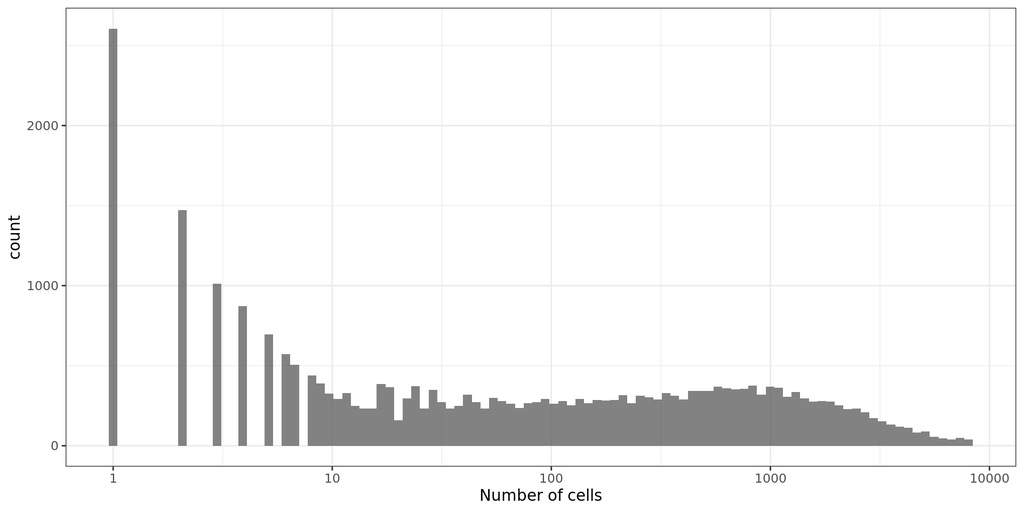

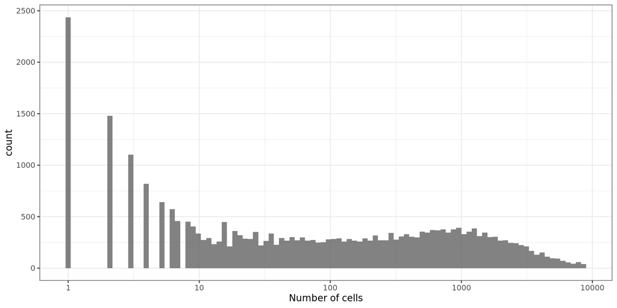

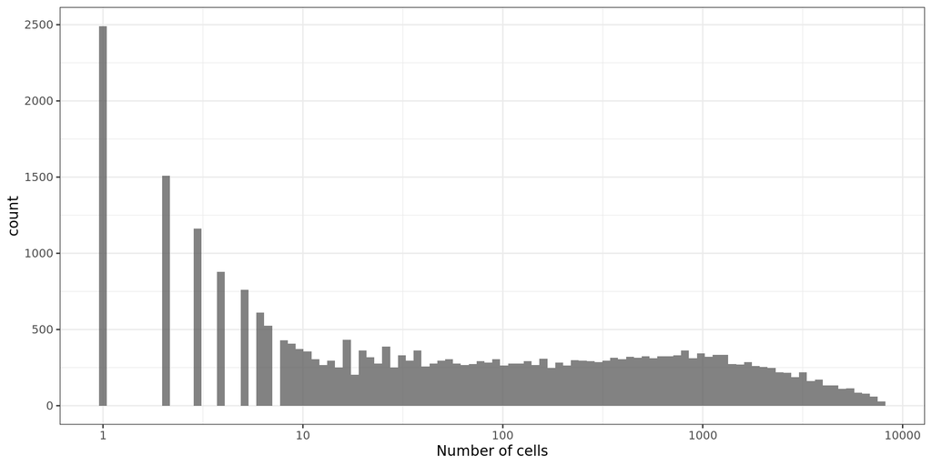

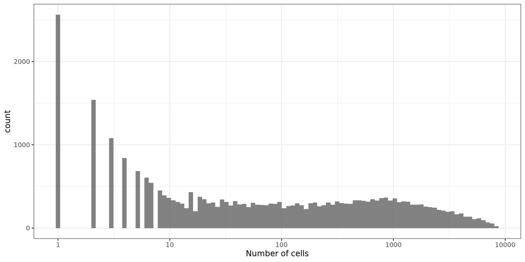

```r
n_cells_list <- map(seurat_list, \(seurat_obj) {
  n_cells <- Matrix::rowSums(seurat_obj[["RNA"]]@counts > 0)
  n_cells
})
gene_qc_ps <- map(n_cells_list, \(n_cells) {
  p <- n_cells %>%
  as.data.frame() %>%
  ggplot(aes(n_cells)) +
    geom_histogram(bins = 100, alpha = 0.75) +
    scale_x_log10("Number of cells") +
    theme_bw()
  p
})
gene_qc_ps
```

## 5.2 Subset genes

```r
# seurat_list
# seurat_list <- map2(seurat_list, n_cells_list, \(seurat_obj, n_cells) {
#   selected_genes <- names(n_cells)[n_cells > min_cells]
#   seurat_obj <- subset(seurat_obj, features = selected_genes)
#   seurat_obj
# })
# seurat_list
```

# 6 Doublet detection

We use [scDblFinder](http://bioconductor.org/books/3.15/OSCA.advanced/doublet-detection.html#computing-doublet-densities):

```r
seurat_list
```

```
## $hagf3y16_sldip2ou
## An object of class Seurat
## 126524 features across 8037 samples within 2 assays
## Active assay: RNA (36601 features, 0 variable features)
##  1 other assay present: ATAC
##
## $k8s4gkxa_phcaecsq
## An object of class Seurat
## 127726 features across 8576 samples within 2 assays
## Active assay: RNA (36601 features, 0 variable features)
##  1 other assay present: ATAC
##
## $ng2o8d1y_g4kzaifb
## An object of class Seurat
## 102700 features across 7852 samples within 2 assays
## Active assay: RNA (36601 features, 0 variable features)
##  1 other assay present: ATAC
##
## $zoxefjul_5m23u91h
## An object of class Seurat
## 104135 features across 8377 samples within 2 assays
## Active assay: RNA (36601 features, 0 variable features)
##  1 other assay present: ATAC
```

```r
seurat_list <- map(seurat_list, \(seurat_obj) {
  seurat_obj <- NormalizeData(seurat_obj)
  seurat_obj <- FindVariableFeatures(seurat_obj)
  sce <- as.SingleCellExperiment(seurat_obj)
  dbl_densities <- computeDoubletDensity(
    sce,
    dims = 30,
    subset.row = VariableFeatures(seurat_obj)
  )
  seurat_obj$doublet_score <- dbl_densities
  seurat_obj$is_doublet <- seurat_obj$doublet_score > 5
  seurat_obj <- seurat_obj[, !seurat_obj$is_doublet]
  seurat_obj
})
seurat_list
```

```
## $hagf3y16_sldip2ou
## An object of class Seurat
## 126524 features across 7675 samples within 2 assays
## Active assay: RNA (36601 features, 2000 variable features)
##  1 other assay present: ATAC
##
## $k8s4gkxa_phcaecsq
## An object of class Seurat
## 127726 features across 8235 samples within 2 assays
## Active assay: RNA (36601 features, 2000 variable features)
##  1 other assay present: ATAC
##
## $ng2o8d1y_g4kzaifb
## An object of class Seurat
## 102700 features across 7510 samples within 2 assays
## Active assay: RNA (36601 features, 2000 variable features)
##  1 other assay present: ATAC
##
## $zoxefjul_5m23u91h
## An object of class Seurat
## 104135 features across 7993 samples within 2 assays
## Active assay: RNA (36601 features, 2000 variable features)
##  1 other assay present: ATAC
```

# 7 Save

```r
saveRDS(seurat_list, here("scRNA-seq/results/R_objects/seurat_objects_revision/1-seurat_object_barcelona_multiome_filtered.rds"))
```